# Practical Machine Learning Course Project

Bikash

May 9, 2017

#### SYNOPSIS

People regularly quantify how much of a particular activity they do, but they rarely quantify how well they do it. In this project, the goal is to use data from accelerometers on the belt, forearm, arm, and dumbell of 6 participants.

The data for this project come from this source: http://groupware.les.inf.puc-rio.br/har. They have been very kind in allowing this data to be used for our Course assignment.

The data consists of training and test sets with the training set containing 19,622 obseravtions of 160 variables and the test set consists of 20 observations for which we need to predict how well the exercise is done from our final model that we decide to choose.

This “how well” measurement is done by the “classe” variable.

Our goal as per the course project also includes:-

1.Creating a report describing how we built our model,

2.How we use cross validation,

3.What the expected out of sample error is,

4.Why you made the choices you did.

We start by including all the packages.

```r
suppressMessages(suppressWarnings(library(caret)))
suppressMessages(suppressWarnings(library(rattle)))
suppressMessages(suppressWarnings(library(rpart.plot)))
suppressMessages(suppressWarnings(library(randomForest)))
```

b)Variables with over 80% of Data missing

```r
a<-NULL
new_data<-read.csv("https://d396qusza40orc.cloudfront.net/predmachlearn/pml-training.csv",head=TRUE,as.is=TRUE)
new_data<-new_data[,-(nzv(new_data))]
for(i in 1:ncol(new_data))
{if(nrow(new_data[is.na(new_data[,i]),])/nrow(new_data)>.8){
a<-cbind(a,i)}
}
new_data<-new_data[,-c(a,1,2)]
new_data$classe<-as.factor(new_data$classe)
```

We now partition the training data furthur into training and test sets:-

```r
inTrain <- createDataPartition(y=new_data$classe, p=0.6,list=FALSE)
myTraining <- new_data[inTrain, ]; myTesting <- new_data[-inTrain, ]
dim(myTraining); dim(myTesting)
```

```
## [1] 11776    57
```

```
## [1] 7846   57
```

```r
myTraining$cvtd_timestamp<-as.Date(myTraining$cvtd_timestamp,'%d/%m/%Y %H:%M')
myTesting$cvtd_timestamp<-as.Date(myTesting$cvtd_timestamp,'%d/%m/%Y %H:%M')
```

First , We now build a classification tree Model

```r
set.seed(400)
modFitCT<-train(classe~.,data = myTraining[,-c(1,2,3)],method="rpart")

predCT<-predict(modFitCT,newdata = myTesting,method="class")
confusionMatrix(predCT,myTesting$classe)
```

```
## Confusion Matrix and Statistics
##
##           Reference
## Prediction    A    B    C    D    E
##          A 2024  658  625  581  217
##          B   43  498   44  226  186
##          C  160  362  699  479  382
##          D    0    0    0    0    0
##          E    5    0    0    0  657
##
## Overall Statistics
##
##                Accuracy : 0.4943
##                  95% CI : (0.4831, 0.5054)
##     No Information Rate : 0.2845
##     P-Value [Acc > NIR] : < 2.2e-16
##
##                   Kappa : 0.3387
##  Mcnemar's Test P-Value : NA
##
## Statistics by Class:
##
##                      Class: A Class: B Class: C Class: D Class: E
## Sensitivity            0.9068  0.32806  0.51096   0.0000  0.45562
## Specificity            0.6293  0.92114  0.78651   1.0000  0.99922
## Pos Pred Value         0.4931  0.49950  0.33573      NaN  0.99245
## Neg Pred Value         0.9444  0.85107  0.88393   0.8361  0.89073
## Prevalence             0.2845  0.19347  0.17436   0.1639  0.18379
## Detection Rate         0.2580  0.06347  0.08909   0.0000  0.08374
## Detection Prevalence   0.5232  0.12707  0.26536   0.0000  0.08437
## Balanced Accuracy      0.7681  0.62460  0.64874   0.5000  0.72742
```

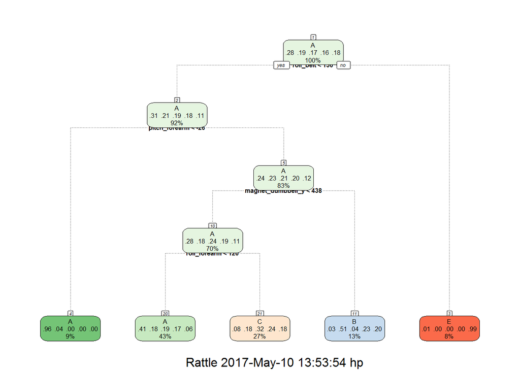

```r
fancyRpartPlot(modFitCT$finalModel,cex=.5,under.cex=1,shadow.offset=0)
```

Then , We build classification tree Model after centering and scaling and also using cross validation with 5 folds

```r
set.seed(400)

tr_ctrl <- trainControl(method = "cv", number = 5)
modFitCTCV<-train(classe~.,data = myTraining[,-c(1,2,3)],method="rpart",trControl = tr_ctrl,preProcess=c("center","scale"))

predCTCV<-predict(modFitCTCV,newdata = myTesting,method="class")
confusionMatrix(predCTCV,myTesting$classe)
```

```
## Confusion Matrix and Statistics
##
##           Reference
## Prediction    A    B    C    D    E
##          A 2024  658  625  581  217
##          B   43  498   44  226  186
##          C  160  362  699  479  382
##          D    0    0    0    0    0
##          E    5    0    0    0  657
##
## Overall Statistics
##
##                Accuracy : 0.4943
##                  95% CI : (0.4831, 0.5054)
##     No Information Rate : 0.2845
##     P-Value [Acc > NIR] : < 2.2e-16
##
##                   Kappa : 0.3387
##  Mcnemar's Test P-Value : NA
##
## Statistics by Class:
##
##                      Class: A Class: B Class: C Class: D Class: E
## Sensitivity            0.9068  0.32806  0.51096   0.0000  0.45562
## Specificity            0.6293  0.92114  0.78651   1.0000  0.99922
## Pos Pred Value         0.4931  0.49950  0.33573      NaN  0.99245
## Neg Pred Value         0.9444  0.85107  0.88393   0.8361  0.89073
## Prevalence             0.2845  0.19347  0.17436   0.1639  0.18379
## Detection Rate         0.2580  0.06347  0.08909   0.0000  0.08374
## Detection Prevalence   0.5232  0.12707  0.26536   0.0000  0.08437
## Balanced Accuracy      0.7681  0.62460  0.64874   0.5000  0.72742
```